# Scrapping de l'API de Twitter, nettoyage du contenu des données récupérées et analyse de sentiments.

Joé Marc & Lorraine Larcher DMDA

[figure not shown]

```python
from IPython.display import Image
Image("twitter.png")
```

Pour réaliser ce projet nous nous sommes appuyer sur différentes sources dont le notebook vu en cours :

- L'api de twitter
- Des exemples d'études de cas en python sur de l'analyse de données via Twitter.

## Préparation de notre environnement de travail

On importe les différentes librairies qui vont nous être nécessaires au bon déroulement du projet ( parfois il faudra les installer via pip ou conda pour pouvoir les importer)

```python
#Importer la librairie tweepy et les méthodes associées
import tweepy
from tweepy.streaming import StreamListener
from tweepy import OAuthHandler
from tweepy import Stream
import json
```

On récupère les différentes clés API en allant sur l'API de twitter https://apps.twitter.com où l'on va créer une app pour obtenir les différentes clés et tokens nécessaires pour accéder et streamer de la data via leur API.

```python
#Entrer les clés de crédits de l'app créer sur Twitter API
#Nous avons bien évidemment supprimer les notres et nous vous invitons à entrer les votre via le lien ci-dessus
CONSUMER_KEY = 'ENTRER CONSUMER KEY'
CONSUMER_SECRET = 'ENTRER SECRET CONSUMER KEY'
ACCESS_TOKEN = 'ENTRER ACCES TOKEN'
ACCESS_TOKEN_SECRET = 'ENTRER ACCESS TOKEN SECRET'
```

### Accès à l'api de Twitter et notre méthode d'accès aux données, scrapping

Nous créons une méthode qui va permettre d'accéder à l'API via nos codes d'accès ci-dessus et va nous renvoyer les tweets en temps réel car nous laissons la connection ouverte (pour l'arrêter il suffit de faire CTRL+ C).

De plus la méthode va nous permettre de 'storer' tout les tweets dans un fichier JSON au meme niveau que ce Notebook dans notre cas

```python
#Un 'listener' qui va nous permettre d'afficher les tweets par la suite
class StdOutListener(StreamListener):

    def on_data(self, data):
        try:
            with open('orient.json', 'a') as f:
                f.write(data)
                return True
        except BaseException as e:
            print("Error on_data: %s" % str(e))
        return True

    def on_error(self, status):
        print(status)
        return True

    def on_error(self, status):
        print(status)


if __name__ == '__main__':

    #Appelle l'API de tweeter pour nous authentifier et ainsi nous ouvrir l'accès
    status = StdOutListener()
    auth = tweepy.OAuthHandler(CONSUMER_KEY, CONSUMER_SECRET)
    auth.set_access_token(ACCESS_TOKEN, ACCESS_TOKEN_SECRET)
    api = tweepy.API(auth)
    stream = Stream(auth, status)

    #Demande a Twitter de renvoyer les tweets selon les mots clés à spécifier ci-dessous
    stream.filter(track=['Lebanon','Israel','Middle east', 'Syria'])
```

```
401
401
```

[output not shown]

Après avoir interrompu avec la commande (CMD+C dans le cas d'un mac / CTRL+C dans le cas d'un windows), vous pouvez aller consulter votre nouveau fichier JSON contenant toutes les données provenant d'un tweet.

Ici nous allons commencer le pré-traitement de nos tweets en l'enregistrant dans une variable qui va nous permettre d'appeller et d'obtenir le contenu de notre fichier JSON plus simplemenent. Ici nous l'appelerons 'tweets'

```python
tweet_files = ['orient.json']
tweets = []
for file in tweet_files:
    with open(file, 'r') as f:
        for line in f.readlines():
            tweets.append(json.loads(line))
```

On affiche les Tweets obtenus

```python
tweets
```

[output not shown]

[output cut: 53423 more lines]

[output not shown]

```python
print(" Taille du corpus de l'article 2 : {}".format(len(tweets)))
```

```
 Taille du corpus de l'article 2 : 300
```

### Tokenisation de notre flux de données

Ici nous allons "Tokeniser" notre flux de data en isolant les différents caractères (string, emoticones, mentions, Tags HTML etc...)

```python
import re

emoticons_str = r"""
    (?:
        [:=;] # Eyes
        [oO\-]? # Nose (optional)
        [D\)\]\(\]/\\OpP] # Mouth
    )"""

regex_str = [
    emoticons_str,
    r'<[^>]+>', # HTML tags
    r'(?:@[\w_]+)', # @-mentions
    r"(?:\#+[\w_]+[\w\'_\-]*[\w_]+)", # hash-tags
    r'http[s]?://(?:[a-z]|[0-9]|[$-_@.&amp;+]|[!*\(\),]|(?:%[0-9a-f][0-9a-f]))+', # URLs

    r'(?:(?:\d+,?)+(?:\.?\d+)?)', # numbers
    r"(?:[a-z][a-z'\-_]+[a-z])", # words with - and '
    r'(?:[\w_]+)', # other words
    r'(?:\S)' # anything else
]

tokens_re = re.compile(r'('+'|'.join(regex_str)+')', re.VERBOSE | re.IGNORECASE)
emoticon_re = re.compile(r'^'+emoticons_str+'$', re.VERBOSE | re.IGNORECASE)

def tokenize(s):
    return tokens_re.findall(s)

def preprocess(s, lowercase=False):
    tokens = tokenize(s)
    if lowercase:
        tokens = [token if emoticon_re.search(token) else token.lower() for token in tokens]
    return tokens
```

Nous importons 2 nouvelles librairies, qui vont nous permettre d'afficher les mots après notre process de tokenisation mais aussi nous permettre d'afficher leur nombre d'occurences.

```python
import operator
from collections import Counter
```

```python
with open('orient.json', 'r') as f:
    count_all = Counter()
    for line in f:
        tweet = json.loads(line)
        tokens = preprocess(tweet['text'])
        tweet = json.loads(line)
        # Create a list with all the terms
        terms_all = [term for term in preprocess(tweet['text'])]
        # Update the counter
        count_all.update(terms_all)
        # Print the first 5 most frequent words
        print(count_all.most_common(5))
        print(tokens)
```

```
[('the', 3), ('On', 2), ('left', 2), ('RT', 1), ('@pale2018', 1)]
['RT', '@pale2018', ':', 'On', 'the', 'left', 'an', 'ancient', '#Hebrew', 'On', 'the', 'right', 'a', 'self-proclaimed', 'Hebrew', '.', 'They', 'left', 'the', 'Middle', 'East', 'black', 'and', 'came', 'back', 'white', 'It', "'", '…']
[('the', 3), (':', 2), ('On', 2), ('left', 2), ('and', 2)]
['Lebanese', 'Municipalities', ':', 'Stop', 'killing', 'Stray', 'Dogs', 'and', 'Animals', 'in', 'Lebanon', 'https://t.co/EPGwCTZBEE', 'via', '@Change']
[('the', 4), ('and', 3), ('in', 3), (':', 2), ('On', 2)]
['@nypost', 'Of', 'course', 'in', 'the', 'world', '.', 'Very', 'popular', 'in', 'Syria', ',', 'Iraq', ',', 'and', 'every', 'socialist', 'nation']
[('the', 6), ('in', 4), (':', 3), ('and', 3), ('RT', 2)]
['RT', '@AmyMek', ':', 'The', 'persecution', '&', 'amp', ';', 'slaughter', 'of', 'Christians', 'in', 'the', 'Middle', 'East', 'by', 'the', '"', 'Religion', 'of', 'Peace', '"', 'continues', 'to', 'be', 'IGNORED', 'by', 'Liberal', 'Medi', '…']
[('the', 9), ('and', 6), ('.', 5), ('in', 5), (':', 3)]
['Putin', 'and', 'Assad', 'wiped', 'Aleppo', 'and', 'its', 'people', 'off', 'the', 'face', 'of', 'the', 'Earth', '.', '.', '.', 'and', 'now', "they're", 'back', 'to', 'finish', 'the', 'job', 'in', '…', 'https://t.co/H9U10Jqkyn']
[('the', 9), ('and', 6), ('.', 5), ('in', 5), (':', 3)]
['#ksa', '#saudi', '#egypt', '#Syria', '#Yemen', '#Sudan', '#uae', '#kuwait', '#Bahrain', '#morroco', '#Algerie', '#Lebanon', '#Iraq', '#Qatar', '#oman', '#Libya', '#tunisie', '#Jordan', '#q8']
[('the', 10), ('.', 6), ('and', 6), ('in', 5), (':', 4)]
['RT', '@Partisangirl', ':', 'Two', 'baby', 'boys', 'dead', 'on', 'a', 'beach', '.', 'One', 'of', 'them', 'drowned', 'on', 'his', 'way', 'to', 'Europe', ',', 'the', 'other', 'was', 'killed', 'on', 'purpose', 'by', '#israeli', 'forc', '…']
[('the', 10), ('.', 10), ('and', 6), ('…', 5), ('in', 5)]
['مما', 'كتب', '#وجدي_الحمدان', 'الكل', 'ناسي', '#المعتقلين', '.', '.', 'الكل', 'ملتهي', 'شو', 'بدو', 'يعمل', 'براس', 'السنة', '.', '.', 'وناسين', 'حديث', 'عن', 'رسول', 'الله', '(', 'من', '…', 'https://t.co/Ko0t4b242s']
[('.', 11), ('the', 10), ('and', 7), (',', 6), ('…', 5)]
['War', 'is', "US's", 'Business', '!', 'After', 'Afghanistan', ',', 'iraq', ',', 'Lebnan', ',', 'yamin', 'and', 'syria', '!', 'Pakistan', 'is', 'on', '"', 'Notice', '"', '.', 'https://t.co/KObCCAp4ui']
[('.', 16), ('the', 11), ('and', 7), (',', 6), ('…', 5)]
['How', 'the', '#propagandaWars', 'work', '.', '.', '.', '.', 'Baffle', 'them', 'with', 'alternative', 'facts', '.', '#GoFigure', 'https://t.co/rkKfAFwEEd']
[('.', 16), ('the', 11), ('and', 7), ('in', 7), (',', 6)]
['RT', '@therussophile', ':', 'Syria', 'advances', 'in', 'Idlib', 'as', 'evacuations', 'continue', 'in', 'Eastern', 'Ghouta', 'https://t.co/hBDfHIgQS0']
[('.', 16), ('the', 11), ('and', 7), ('in', 7), (':', 6)]
['RT', '@warsmonitoring', ':', 'Members', 'of', 'Special', 'Operation', 'Force', '-', 'often', 'mention', 'importance', 'of', 'thermal', '/', 'night', 'vision', 'sights', '/', 'goggles', 'that', 'provides', 'them', '…']
[('.', 16), ('the', 11), (',', 9), ('and', 7), ('…', 7)]
['Amid', 'Security', 'Concerns', ',', '#US', 'To', 'Move', '#Egypt', ',', '#Jordan', ',', '#Lebanon', '#Embassies', 'To', '#Jerusalem', 'Also', '|', '@POTerritory', '…', 'https://t.co/jc6kp5bJG7']
[('.', 16), ('the', 11), (',', 11), ('and', 8), ('…', 8)]
['“', 'If', 'however', 'I', 'can', 'make', 'something', 'beautiful', 'out', 'of', 'something', 'so', 'ugly', ',', 'and', 'help', 'preserve', 'my', 'country', '’', 's', 'culture', ',', 'then', 'I', '…', 'https://t.co/OzJnzkDCBA']
[('.', 17), ('the', 12), (',', 12), ('and', 8), ('…', 8)]
['It', '’', 's', 'fucking', 'disgusting', 'seeing', 'these', 'videos', 'of', 'these', 'cruel', ',', 'heartless', 'people', 'killing', 'dogs', 'around', 'Lebanon', '.', 'What', 'the', 'fuck', 'is', 'wrong', 'with', 'them', '?']
[('.', 17), ('the', 12), (',', 12), ('and', 8), ('…', 8)]
['RT', '@RosieBlau', ':', 'Extraordinary', 'if', 'true', 'https://t.co/IzF5P5dNep']
[('.', 17), ('the', 12), (',', 12), ('…', 9), ('and', 8)]
['@MichaelKugelman', 'ISIS', 'terrorists', 'have', 'been', 'transferred', 'from', 'Syria', '/', 'Iraq', 'after', 'their', 'defeat', 'by', 'Russian', '/', 'Iranian', 'forces', '…', 'https://t.co/GcRywGANzr']
[('.', 18), ('the', 14), (',', 12), ('…', 10), ('of', 9)]
['@iamjasonbailey', '@NightBird1965g', '@POTUS', '🇺', '🇸', 'We', 'the', 'people', 'APPROVE', 'of', 'the', 'job', 'President', 'Trump', 'is', 'doing', '.', '🇺', '🇸', 'Just', 'get', 'us', 'o', '…', 'https://t.co/dBa08mULRl']
[('.', 18), ('the', 14), (',', 12), ('…', 11), ('of', 9)]
['@Stratfor', '@StateDept', 'READ', '/', 'DIGEST', '@bbclysedoucet', '@BBCMiddleEast', '@ft', '@wsj', '@XHNews', '@Forbes', '@ChristianeAmanp', '…', 'https://t.co/ktZmuOMtzB']
[('.', 18), ('the', 14), (',', 12), ('…', 11), ('of', 9)]
['RT', '@LayaliKaram', ':', '#NajwaKaram2017', 'Trending', 'in', 'SYRIA', '❤', '!', '@najwakaram', '#نجوى_كرم', 'https://t.co/rWPn5GkGUC']
```

[output cut: 545 more lines]

```
['RT', '@realDonaldTrump', ':', '“', 'On', '1', '/', '20', '-', 'the', 'day', 'Trump', 'was', 'inaugurated', '-', 'an', 'estimated', '35,000', 'ISIS', 'fighters', 'held', 'approx', '17,500', 'square', 'miles', 'of', 'territ', '…']
[(':', 241), ('.', 202), ('…', 197), ('RT', 185), (',', 155)]
['RT', '@m_ebrahimi1', ':', '#Demonstrations_in_Iran', 'spreading', 'from', '#Mashhad', 'to', 'other', 'cities', ',', 'including', '#Kermanshah', '.', 'People', 'voicing', 'political', 'demands', '&', 'amp', ';', '…']
[(':', 242), ('.', 202), ('…', 198), ('RT', 186), (',', 158)]
['RT', '@pierrelecorf', ':', 'Un', 'an', 'en', 'arri', 'ère', ',', 'avant', 'la', 'lib', 'ération', ',', 'les', 'derniers', 'bus', 'de', 'djihadistes', '(', 'ici', 'Al-Qa', 'ïda', ')', 'partaient', ',', 'ils', 'pouvaient', 'quitter', 'Al', '…']
[(':', 243), ('.', 202), ('…', 199), ('RT', 187), (',', 158)]
['RT', '@Linashamy', ':', 'Horrible', 'massacres', 'in', 'Syria', 'now', 'by', 'Russia', '&', 'amp', ';', 'Assad', 'while', 'a', 'gathering', 'for', 'some', 'human-traffickers', 'in', 'Sochi', 'is', 'being', 'organized', 'b', '…']
[(':', 245), ('.', 202), ('…', 200), ('RT', 188), (',', 158)]
['RT', '@hrw', ':', 'Daily', 'Brief', ':', 'Iran', 'protests', ';', 'Ukraine', 'to', 'probe', "lawyer's", 'murder', ';', 'Syria', 'barrel', 'bombs', ';', 'land', 'activist', 'murders', 'on', 'the', 'rise', ';', 'Hong', 'Kong', 'pro', '…']
[(':', 246), ('.', 203), ('…', 201), ('RT', 189), (',', 158)]
['RT', '@ammaraltahan', ':', 'All', 'of', 'the', 'independent', 'PMUs', 'have', 'already', 'either', 'joined', 'ISF', 'or', 'Joined', 'Hashd', 'as', 'part', 'of', 'defense', 'system', '.', 'No', 'Iraqi', 'will', 'ever', '…']
[(':', 247), ('.', 203), ('…', 202), ('RT', 190), (',', 158)]
['RT', '@TheArabSource', ':', 'Syrian', 'Army', 'demands', 'Islamist', 'rebels', 'surrender', 'immediately', 'in', 'east', '#Damascus', 'suburb', 'https://t.co/vNke7u9rRs', '#Harasta', '#Syr', '…']
[(':', 247), ('.', 203), ('…', 202), ('RT', 190), (',', 158)]
['Video', 'shows', 'reporter', 'injured', 'while', 'covering', 'war', 'in', 'Syria', '|', 'World', 'Military', 'News', 'https://t.co/4c2nxKR79A']
```

Nous créons une liste vide qui sera destiné a contenir tout les contenus texte des tweets, on y accède avec la clé 'text', en effet l'API de twitter nous explique comment le faire : https://developer.twitter.com/en/docs/tweets/data-dictionary/overview/tweet-object

```python
tweet_text = []

for tweet in tweets:
    print(tweet['text'])
    print('\n')

for tweet in tweets:
    tweet_text.append(tweet['text'])
```

```
RT @pale2018: On the left an ancient #Hebrew On the right a self-proclaimed Hebrew. They left the Middle East black and came back white It'…


Lebanese Municipalities: Stop killing Stray Dogs and Animals in Lebanon https://t.co/EPGwCTZBEE via @Change


@nypost Of course in the world.  Very popular in Syria, Iraq, and every socialist nation


RT @AmyMek: The persecution &amp; slaughter of Christians in the Middle East by the "Religion of Peace" continues to be IGNORED by Liberal Medi…


Putin and Assad wiped Aleppo and its people off the face of the Earth... and now they're back to finish the job in… https://t.co/H9U10Jqkyn


#ksa #saudi #egypt #Syria #Yemen #Sudan #uae #kuwait #Bahrain #morroco #Algerie #Lebanon #Iraq #Qatar #oman #Libya #tunisie #Jordan #q8


RT @Partisangirl: Two baby boys dead on a beach. One of them drowned on his way to Europe, the other was killed on purpose by #israeli forc…


مما كتب #وجدي_الحمدان
الكل ناسي #المعتقلين  ..
الكل ملتهي شو بدو يعمل براس السنة..
وناسين حديث عن رسول الله
(من… https://t.co/Ko0t4b242s


War is US's Business !
After Afghanistan, iraq, Lebnan,yamin and syria ! Pakistan is on " Notice" . https://t.co/KObCCAp4ui


How the #propagandaWars work.... Baffle them with alternative facts.
#GoFigure https://t.co/rkKfAFwEEd


RT @therussophile: Syria advances in Idlib as evacuations continue in Eastern Ghouta https://t.co/hBDfHIgQS0


RT @warsmonitoring: Members of Special Operation Force - often mention importance of thermal/night vision sights/goggles that provides them…
```

[output cut: 1032 more lines]

```


RT @Linashamy: Horrible massacres in Syria now by Russia &amp; Assad while a gathering for some human-traffickers in Sochi is being organized b…


RT @hrw: Daily Brief: Iran protests; Ukraine to probe lawyer's murder; Syria barrel bombs; land activist murders on the rise; Hong Kong pro…


RT @ammaraltahan: All of the independent PMUs have already either joined ISF or Joined Hashd as part of defense system. No Iraqi will ever…


RT @TheArabSource: Syrian Army demands Islamist rebels surrender immediately in east #Damascus suburb https://t.co/vNke7u9rRs #Harasta #Syr…


Video shows reporter injured while covering war in Syria | World Military News https://t.co/4c2nxKR79A
```

```python
tweet_text
```

```
["RT @pale2018: On the left an ancient #Hebrew On the right a self-proclaimed Hebrew. They left the Middle East black and came back white It'…",
 'Lebanese Municipalities: Stop killing Stray Dogs and Animals in Lebanon https://t.co/EPGwCTZBEE via @Change',
 '@nypost Of course in the world.  Very popular in Syria, Iraq, and every socialist nation',
 'RT @AmyMek: The persecution &amp; slaughter of Christians in the Middle East by the "Religion of Peace" continues to be IGNORED by Liberal Medi…',
 "Putin and Assad wiped Aleppo and its people off the face of the Earth... and now they're back to finish the job in… https://t.co/H9U10Jqkyn",
 '#ksa #saudi #egypt #Syria #Yemen #Sudan #uae #kuwait #Bahrain #morroco #Algerie #Lebanon #Iraq #Qatar #oman #Libya #tunisie #Jordan #q8',
 'RT @Partisangirl: Two baby boys dead on a beach. One of them drowned on his way to Europe, the other was killed on purpose by #israeli forc…',
 'مما كتب #وجدي_الحمدان \nالكل ناسي #المعتقلين  .. \nالكل ملتهي شو بدو يعمل براس السنة.. \nوناسين حديث عن رسول الله \n(من… https://t.co/Ko0t4b242s',
 'War is US\'s Business ! \nAfter Afghanistan, iraq, Lebnan,yamin and syria ! Pakistan is on " Notice" . https://t.co/KObCCAp4ui',
 'How the #propagandaWars work.... Baffle them with alternative facts.\n#GoFigure https://t.co/rkKfAFwEEd',
 'RT @therussophile: Syria advances in Idlib as evacuations continue in Eastern Ghouta https://t.co/hBDfHIgQS0',
 'RT @warsmonitoring: Members of Special Operation Force - often mention importance of thermal/night vision sights/goggles that provides them…',
 'Amid Security Concerns, #US To Move #Egypt, #Jordan, #Lebanon #Embassies To #Jerusalem Also | @POTerritory… https://t.co/jc6kp5bJG7',
 '“If however I can make something beautiful out of something so ugly, and help preserve my country’s culture, then I… https://t.co/OzJnzkDCBA',
 'It’s fucking disgusting seeing these videos of these cruel, heartless people killing dogs around Lebanon. What the fuck is wrong with them?',
 'RT @RosieBlau: Extraordinary if true https://t.co/IzF5P5dNep',
 '@MichaelKugelman ISIS terrorists have been transferred from Syria/Iraq after their defeat by Russian/Iranian forces… https://t.co/GcRywGANzr',
 '@iamjasonbailey @NightBird1965g @POTUS 🇺🇸We the people APPROVE of the job President Trump is doing.🇺🇸 Just get us o… https://t.co/dBa08mULRl',
 '@Stratfor @StateDept READ /DIGEST @bbclysedoucet @BBCMiddleEast @ft @wsj @XHNews @Forbes @ChristianeAmanp… https://t.co/ktZmuOMtzB',
 'RT @LayaliKaram: #NajwaKaram2017  Trending in SYRIA ❤! @najwakaram \n#نجوى_كرم https://t.co/rWPn5GkGUC',
 'Cyprus frequent visits to Lebanon is to convince us to install all the oil and gas infrastructure for the region on… https://t.co/XmOGAkC4cK',
 'RT @ahmedhijazi96: 🇵🇸 #Palestine: Israel !! The only democracy in the Middle East. https://t.co/1Gd0zL4ohP',
 '#forex #bitcoin #gold #oil #technical #money #profits #Lebanon #Dubai #Saudi_Arabia #crude_oil #technical_analysis… https://t.co/nY1ywR8nC0',
 'See my story: "Middle East" https://t.co/noPBX1br2N #SparkMade via @AdobeSpark',
 'RT @MasoumehMirzaee: #Kermanshah -29 Dec 2017 - Public #protest against high prices continue in (Western Iran)\n"Not Gaza, Not Lebanon, My l…',
 'RT @Geostrat_ME: #US and #Israel formulate a plan to stop #Iran together \n\nTop US and Israeli national #security officials reached an agree…',
 'We condemn ISIS - yet sell bombs to the Saudis. Hypocrisy abounds.  https://t.co/SBysWSneWr',
 'RT @Partisangirl: @BalmainFletch @Osman_Marwa1 Then why is the age of marriage in syria 18, but not in california? and why is it that these…',
 'RT @CNN: More than a dozen animals rescued from a zoo outside Aleppo, Syria, have found a new home in Jordan https://t.co/3zeT9x5ngt https:…',
 'PROSHRED has partnered with ShredEx in the Middle East #Security #Shredding #Services https://t.co/wVrxQ7dlk9',
 'Jeddah Jobs | Emergency Medicine Consultant\nJobLink: https://t.co/NqEAlkV9WX\n#Jobs #Job #Hiring #ERPhysician… https://t.co/CXDkR7VuaC',
 'RT @RonanLTynan: Another dark hour in New Dark Age as #Assad and #Putin pound civilians with impunity in #Idlib #Syria? Continuing crimes w…',
 'https://t.co/rki7PPm5b5 I Choose Financial Freedom https://t.co/boESY96F2T #success #forex #currency #investing… https://t.co/GcRP1IQ8CV',
 "RT @TrickFreee: Putin and Assad wiped Aleppo and its people off the face of the Earth... and now they're back to finish the job in Idlib. h…",
 'Unstoppable: Elite Syrian forces liberate yet another key town in #Idlib en-route to Khan Sheikhoun https://t.co/VAXblntue8  #Syria',
 'RT @TheArabSource: Unstoppable: Elite Syrian forces liberate yet another key town in #Idlib en-route to Khan Sheikhoun https://t.co/4BfHQl1…',
 'RT @VanessaBeeley: Joud Haider 3.5 yrs old. #Damascus #Syria. Joud has Hydrocephalus, liquid in the brain - he is deteriorating rapidly, hi…',
 'Thread: https://t.co/hlrvQ7hEiK',
 'RT @cezarysta: @michaeldweiss #Soviet “Acquisition and Preparation”, second file revealed by .@michaeldweiss, focuses on #MENA region. It e…',
 "RT @MSuchkov_ALM: THREAD: 1. (Almost) Everything you wanted to know about #Russia's military operation in #Syria. Rus Chief of General Staf…",
```

[output cut: 245 more lines]

```
 "Impacting Syrian Refugees with Jesus' Love The Middle East is witnessing https://t.co/eTCRZQdIHW #nationsmagazine https://t.co/XhX46ZyKFT",
 "RT @Office_AQPk: Now: anti-govt protest in #Mashhad. Protesters chant 'No #Gaza or #Lebanon, my life only for #Iran'.\n\nhttps://t.co/jro9wsJ…",
 'RT @TheArabSource: Unstoppable: Elite Syrian forces liberate yet another key town in #Idlib en-route to Khan Sheikhoun https://t.co/4BfHQl1…',
 'RT @JWalkLNP: Boys Hoops: Congrats to Columbia, Ephrata, Hempfield, Lancaster Mennonite, Lampeter-Strasburg, Penn Manor and Conestoga Valle…',
 'RT @MintPressNews: Russia claims the U.S. is training former #ISIS fighters at Tanf. Does the possibility surprise you? #Syria #Russia\nhttp…',
 '@indiegop The meaning of this slogan is this:\nPeople do not want the Iranian regime to send its troops to Lebanon,… https://t.co/DOSLvqozH1',
 "RT @NupeldaRojava: ABD'nin #YPG'ye yeni gönderdiği silah ve mühimmat yardım konvoyu Rojava'ya geldi. \n\n#TwitterKurds #Syria https://t.co/hJ…",
 'RT @realDonaldTrump: “On 1/20 - the day Trump was inaugurated - an estimated 35,000 ISIS fighters held approx 17,500 square miles of territ…',
 'RT @m_ebrahimi1: #Demonstrations_in_Iran spreading from #Mashhad to other cities, including #Kermanshah. People voicing political demands &amp;…',
 'RT @pierrelecorf: Un an en arrière, avant la libération, les derniers bus de djihadistes (ici Al-Qaïda) partaient, ils pouvaient quitter Al…',
 'RT @Linashamy: Horrible massacres in Syria now by Russia &amp; Assad while a gathering for some human-traffickers in Sochi is being organized b…',
 "RT @hrw: Daily Brief: Iran protests; Ukraine to probe lawyer's murder; Syria barrel bombs; land activist murders on the rise; Hong Kong pro…",
 'RT @ammaraltahan: All of the independent PMUs have already either joined ISF or Joined Hashd as part of defense system. No Iraqi will ever…',
 'RT @TheArabSource: Syrian Army demands Islamist rebels surrender immediately in east #Damascus suburb https://t.co/vNke7u9rRs #Harasta #Syr…',
 'Video shows reporter injured while covering war in Syria | World Military News https://t.co/4c2nxKR79A']
```

L'étape suivante va être de transformer notre liste en contenu texte, qui nous servira pour la suite de l'analyse de sentiment et notre nuage de mots. Car les libraires TEXT blob et wordcloud ne comprennent pas les objets de type liste.

```python
tweet_text_as_string = ''.join(tweet_text)
```

```python
tweet_text_as_string
```

```
'RT @pale2018: On the left an ancient #Hebrew On the right a self-proclaimed Hebrew. They left the Middle East black and came back white It\'…Lebanese Municipalities: Stop killing Stray Dogs and Animals in Lebanon https://t.co/EPGwCTZBEE via @Change@nypost Of course in the world.  Very popular in Sy…
```

### Analyse de sentiments

On importe la librairie TextBlob (installer via les commandes pip ou conda si vous n'arrivez pas à l'importer). Celle-ci va nous permettre de faire une analyse de sentiment avec la notion de polarité et de subjectivité qui la compose.

```python
from textblob import TextBlob

blob = TextBlob(tweet_text_as_string)

tweets_sentiment = blob.sentiment
tweets_polarity = tweets_sentiment[0]
tweets_subjectivity = tweets_sentiment[1]
```

```python
print(" Polarity :" , tweets_polarity)
```

```
 Polarity : 0.06170392969099864
```

L'analyse de la polarité des tweets démontre une certaine neutralité de ceux-ci la valeur 0 étant neutre, -1 négatif, 1 positif. Sur un sujet sensible comme le moyen-orient cela peux nous montré une certaines opposition entre les points de vues, les soutiens à différents partis et pays.

```python
print(" Subjectivité :" , tweets_subjectivity)
```

```
 Subjectivité : 0.3887217370751851
```

Etant donné que la data provient de twitter, nous partons d'un constat de base qui est qu'il peut y avoir beaucoup de tweet subjectif comme des simples liens. Pourtant ici notre analyse de subjectivité nous démontre que nos tweets sont plutôt objectifs car plus proche de la valeur 0 que 1. Nous pouvons donc dire qu'il y a de vrais échanges concernant ce sujet sur twitter, malgré une minorité de tweets subjectifs.

### Nuage de Mots

On importe la librairie WordCloud (installer via les commandes pip ou conda si vous n'arrivez pas à l'importer). Ici nous pourrons obtenir un nuage de mots les plus redondants dans un premier temps.

```python
from wordcloud import WordCloud
from wordcloud import STOPWORDS
import matplotlib.pyplot as plt
```

[figure not shown]

```python
wordcloud = WordCloud(
                      stopwords=STOPWORDS,
                      background_color='white',
                      max_words=1000,
                      width=1800,
                      height=1400,
                     ).generate(tweet_text_as_string)
plt.imshow(wordcloud)
plt.axis('off')
plt.show()
```

Comme nous pouvions nous en douter, le nuage de mot ne nous délivre pas que de la bonne information. Il va falloir encore plus nettoyer notre flux de données si nous voulons en obtenir un meilleur.

Nous allons faire cela en important la libraire NLTK, qui va nous permettre avec son module stopwords, de supprimer tout les mots de ponctuation et plus si nous en spécifions de la langue choisie

```python
import nltk
nltk.download('stopwords')
```

```
True
```

```python
from nltk.corpus import stopwords
import string

punctuation = list(string.punctuation)
stop = stopwords.words('english') + punctuation + ['RT', 'via','null', 'https', 'href=\\','source','id_str','in_reply_to_user_id','in_reply_to_user_id_str','in_reply_to_screen_name', 'idlib']
```

```python
stop
```

```
['i',
 'me',
 'my',
 'myself',
 'we',
 'our',
 'ours',
 'ourselves',
 'you',
 "you're",
 "you've",
 "you'll",
 "you'd",
 'your',
 'yours',
 'yourself',
 'yourselves',
 'he',
 'him',
 'his',
 'himself',
 'she',
 "she's",
 'her',
 'hers',
 'herself',
 'it',
 "it's",
 'its',
 'itself',
 'they',
 'them',
 'their',
 'theirs',
 'themselves',
 'what',
 'which',
 'who',
 'whom',
 'this',
```

[output cut: 167 more lines]

```
 '{',
 '|',
 '}',
 '~',
 'RT',
 'via',
 'null',
 'https',
 'href=\\',
 'source',
 'id_str',
 'in_reply_to_user_id',
 'in_reply_to_user_id_str',
 'in_reply_to_screen_name',
 'idlib']
```

Après avoir vu quels mots et caractères nous ne voulions pas nous faisons une méthodes qui va nous permettre de récupérer les mots qui ne sont pas égaux aux stopwords de la liste 'stop' ci-dessus

```python
from nltk.tokenize import word_tokenize

all_tokens1_bis = []
for t in word_tokenize(tweet_text_as_string, language='english') :
    if len(t)>3:
        all_tokens1_bis.append(t)

all_tokens1_bis
```

```
['pale2018',
 'left',
 'ancient',
 'Hebrew',
 'right',
 'self-proclaimed',
 'Hebrew',
 'They',
 'left',
 'Middle',
 'East',
 'black',
 'came',
 'back',
 'white',
 "It'…Lebanese",
 'Municipalities',
 'Stop',
 'killing',
 'Stray',
 'Dogs',
 'Animals',
 'Lebanon',
 'https',
 '//t.co/EPGwCTZBEE',
 'Change',
 'nypost',
 'course',
 'world',
 'Very',
 'popular',
 'Syria',
 'Iraq',
 'every',
 'socialist',
 'nationRT',
 'AmyMek',
 'persecution',
 'slaughter',
 'Christians',
```

[output cut: 946 more lines]

```
 'chanti…',
 'https',
 '//t.co/5vH2Pcq4y4RT',
 'WarpedMirrorPMB',
 'Tamimi',
 'father',
 'argues',
 'that',
 'blonde',
 'hair',
 'Western',
 'dress',
 'have',
 'contributed',
 ...]
```

Ici nous allons afficher les termes les plus communs de la liste nettoyés que nous avons obtenus ci-dessus

```python
tokens_no_stop = []
for token in all_tokens1_bis:
    if token not in stop:
        tokens_no_stop.append(token)

total_term_frequency_no_stop = Counter(tokens_no_stop)

for word, freq in total_term_frequency_no_stop.most_common(25):
    print("{}\t{}".format(word, freq))
```

```
Syria	81
Lebanon	32
ISIS	27
Middle	25
East	24
الكل	22
Iran	22
Russia	19
Idlib	18
Syrian	15
people	14
Trump	14
fighters	14
realDonaldTrump	14
Assad	12
الله	12
وجدي_الحمدان	11
ناسي	11
المعتقلين	11
ملتهي	11
يعمل	11
براس	11
السنة..	11
وناسين	11
حديث	11
```

```python
total_term_frequency_no_stop.values()
```

```
dict_values([1, 3, 1, 2, 3, 1, 4, 25, 24, 1, 1, 5, 1, 1, 1, 1, 2, 1, 1, 1, 32, 1, 1, 1, 3, 3, 1, 1, 81, 10, 2, 1, 1, 5, 4, 4, 7, 4, 5, 4, 4, 4, 1, 12, 4, 9, 14, 6, 4, 4, 1, 1, 1, 4, 1, 1, 1, 1, 1, 2, 1, 2, 1, 7, 1, 3, 1, 1, 1, 1, 1, 2, 6, 1, 1, 1, 11, 22, 11, 11, 11, 11, 11, 11, 11, 11, 11, 12, 1, 1…
```

```python
scored = {}
for w, f in total_term_frequency_no_stop.most_common(100):
    relative_tf = f / sum(total_term_frequency_no_stop.values())
    scored[w]  = relative_tf

tfdict
```

[output not shown]

[output cut: 45 more lines]

[output not shown]

```python
scored.items()
```

```
dict_items([('Syria', 0.024493498639250075), ('Lebanon', 0.009676443906864228), ('ISIS', 0.008164499546416692), ('Middle', 0.0075597218022376775), ('East', 0.00725733293014817), ('الكل', 0.006652555185969156), ('Iran', 0.006652555185969156), ('Russia', 0.005745388569700635), ('Idlib', 0.005442999697…
```

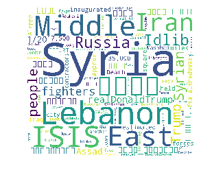

```python
wordcloud = WordCloud(
                      stopwords=STOPWORDS,
                      background_color='white',
                      max_words=2000,
                      width=3800,
                      height=3400,
                     ).generate_from_frequencies(scored)
plt.imshow(wordcloud)
plt.axis('off')
plt.show()
```

Après avoir scoré les mots un à un afin de "processer" les valeurs inutiles à notre nuage de mot tel que des urls, des ID ou encore des champs twitter que nous ne serions pas parvenus à nettoyer plus haut, nous pouvons voir que le resultat est nettement plus révélateur. Des Pays du moyen-orient et les acteurs du moments sont ceux qui apparraissent dans notre nuage de mot ce qui est représentatif de l'actualité et de l'état actuel des choses au Moyen-Orient, avec les mots ISIS, TRUMP, Russia, Syria, Lebanon.